# Assignment Brief UNIT 17 - Business Process Support

Rubén Valverde Romero

24 octubre, 2024

## Validación de datos

El conjunto de datos original contiene 15000 filas y 8 columnas antes de la limpieza y validación. Después de la limpieza, el conjunto de datos restante contiene 14997 filas y 8 columnas.

### Descripción de los datos:

- **week**: Hay 6 valores numéricos únicos que van del 1 al 6. No se requirió limpieza.
- **sales_method**: Hay 3 métodos únicos (“Call”, “Email” y “Email + Call”). Algunos valores fueron corregidos (“em + call” → “Email + Call”, “email”→ “Email”).
- **customer_id**: Contiene valores de caracteres sin valores faltantes, coincidiendo con la descripción proporcionada. No se requirió limpieza.
- **nb_sold**: Esta variable comprende 10 categorías numéricas, que van del 7 al 16, sin valores faltantes, coincidiendo con la descripción proporcionada. No se requirió limpieza.
- **revenue**: Esta variable contiene valores numéricos, pero había 1074 valores faltantes (7.16%). Los valores faltantes fueron interpolados, la primera fila que contenía un valor nulo fue eliminada ya que la interpolación no pudo llenarla.
- **years_as_customer**: Esta variable incluye valores numéricos, sin datos faltantes, pero se identificaron dos valores atípicos: 2 clientes con 47 y 63 años como clientes respectivamente. La tienda ha estado abierta durante 40 años, estas filas fueron eliminadas.
- **nb_site_visits**: Esta variable consiste en valores numéricos sin datos faltantes, coincidiendo con la descripción proporcionada. No se requirió limpieza.
- **state**: Contiene 50 valores de caracteres únicos, sin valores faltantes, coincidiendo con la descripción proporcionada. No se requirió limpieza.

## Información solicitada

### P1: ¿Cuántos clientes hubo para cada enfoque?

#### Métodos de ventas utilizados para la participación del cliente:

El correo electrónico fue el más popular, con 7464 clientes eligiendo este método. Su popularidad puede atribuirse a su rentabilidad.

El segundo enfoque más preferido fueron las llamadas telefónicas, con 4,961 clientes.

El método menos favorecido fue una combinación de correo electrónico y llamadas telefónicas, que atrajo a 2,572 clientes.

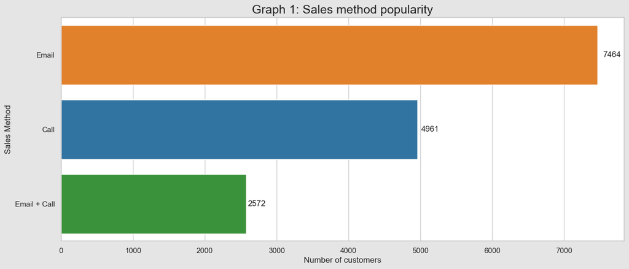

### P2: ¿Cómo se distribuyen los ingresos en general? ¿Y para cada método?

En términos de distribución general de ingresos, exhibe una distribución no normal con una asimetría a la derecha, como se evidencia en el Gráfico 2. Curiosamente, la distribución general de ingresos muestra cinco picos distintos.

Como se muestra en el violinplot del Gráfico 3, estos son el rango intercuartílico (IQR), la mediana y la asimetría de cada método:

**Email**:  
El método con los ingresos totales más altos, como indica el gráfico de barras en el Gráfico 3, esto probablemente se deba a su mayor uso.  
Asimetría: Derecha  
Mediana: 95,34  
IQR: 17,92

**Call**:  
Este método claramente tiene los ingresos totales más bajos y la mediana de ingresos por cliente más baja, como se muestra en los gráficos del Gráfico 3.  
Asimetría: Derecha  
Mediana: 49,83  
IQR: 11,32

**Email + Call**:  
Este método muestra la distribución de ingresos más amplia y la mediana más alta entre los tres métodos, pero también es el que tiene menos clientes, lo que explica por qué todavía está lejos de los ingresos totales del correo electrónico.  
Asimetría: Izquierda  
Mediana: 182,22  
IQR: 39,31

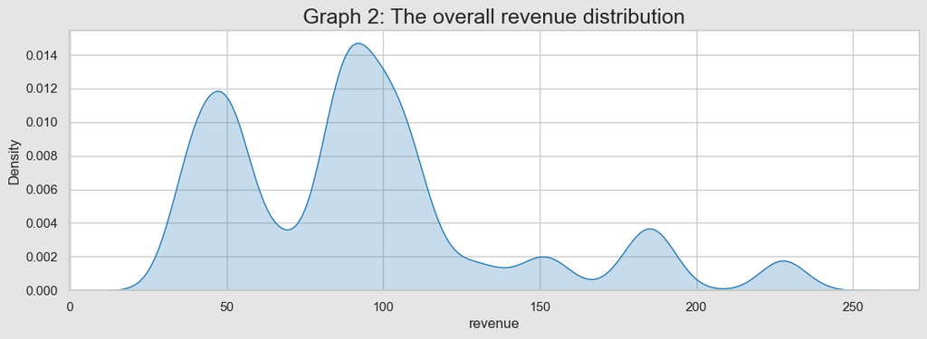

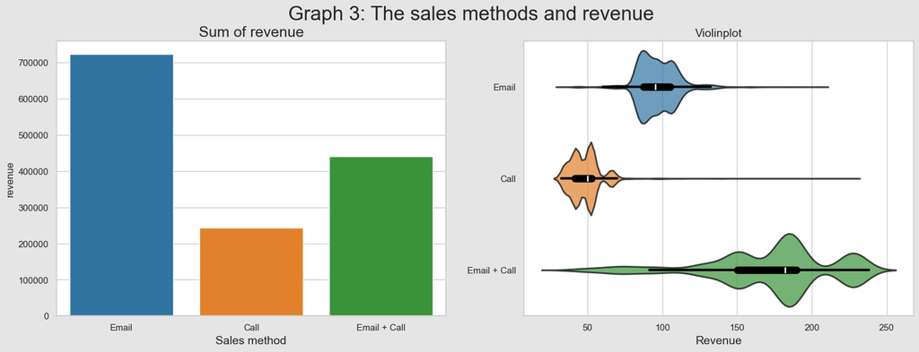

### P3: ¿Hubo alguna diferencia en los ingresos a lo largo del tiempo para cada uno de los métodos?

De hecho, hubo diferencias en las tendencias de ingresos durante las 6 semanas para cada uno de los métodos, como se ilustra en el Gráfico 4.

- El correo electrónico mostró un aumento promedio tanto en términos nominales como porcentuales, con ingresos medios de $88 en la semana 1 y 128 en la semana 6, lo que indica un aumento del 45%.
- El método de llamadas mostró el aumento nominal más pequeño pero el más alto en términos porcentuales, con ingresos medios de $37 en la semana 1 y 67 en la semana 6, lo que resulta en un aumento del 81%.
- En contraste, el método de correo electrónico + llamada experimentó el aumento nominal más significativo. Tuvo ingresos medios de $125 en la semana 1, que aumentaron a 205 en la semana 6, lo que resulta en un aumento del 64%.

Todos los métodos presentaron un aumento en los ingresos promedio.

[figure not shown]

## P4: Según los datos, ¿qué método recomendarías que continuemos usando?

**Nota:** *Algunos de estos métodos toman más tiempo del equipo, por lo que pueden no ser los mejores para usar si los resultados son similares.*

Dado que cada tiempo toma una cantidad diferente de tiempo y, por lo tanto, esfuerzo, sería prudente calcular los ingresos promedio por unidad de tiempo (minuto) en cada método de ventas.

Debido a que el tiempo que toma el método de correo electrónico es indeterminado, el Gráfico 5 muestra la evolución de los ingresos promedio por unidad de tiempo a medida que el método de correo electrónico toma más tiempo.

- El método de llamada es constante ya que siempre toma aproximadamente 30 minutos.
- El método de correo electrónico es completamente variable, pero probablemente toma menos de 2 minutos.
- En el método de correo electrónico + llamada, la parte de ‘llamada’ toma un tiempo constante de 10 minutos y la parte de ‘correo electrónico’ es variable como el método anterior.

Estos son los ARM (ingresos promedio por minuto) de los tres métodos de ventas:

- Correo electrónico:
  - 1 min: $95
  - 2 min: $48
  - 3 min: $32
- Llamada: Su ARM es tan bajo como $1,66
- Correo electrónico + llamada:
  - 11 min: $16,5
  - 12 min: $15
  - 13 min: $14

Como se muestra en el Gráfico 5, el método de correo electrónico es, con mucho, el más rentable, especialmente si toma menos de 2 minutos, lo cual es razonable. Por otro lado, el método de llamada se destaca por su ineficiencia extremadamente alta.

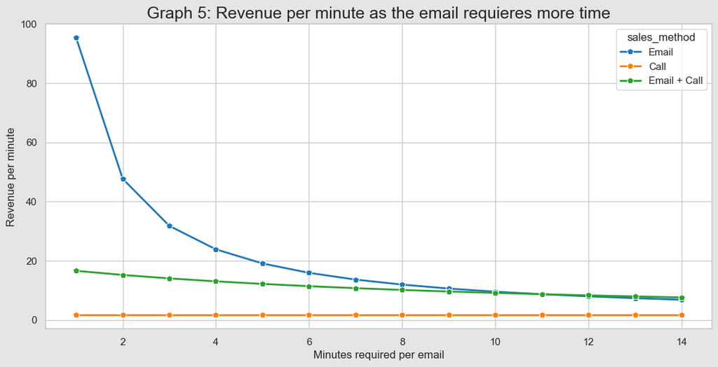

## Métricas de negocio:

En busca del objetivo de la empresa de maximizar los ingresos utilizando el método de ventas más efectivo, recomiendo adoptar los ingresos promedio generados por su método de ventas preferido como una métrica de rendimiento crucial.

Basado en el análisis de datos:

- El método de correo electrónico + llamada emerge como el mejor desempeño, con los ingresos promedio más altos de $182 por cliente y un rango de ARM de 14 a 16.5 dólares.
- El correo electrónico sigue con un ingreso promedio de $95, pero con un rango de ARM espectacular que va de 95 a 32 dólares en el peor de los casos.
- El método de llamada queda rezagado con el ingreso promedio más bajo, situándose en $50 y su ARM no lo mejora, ni siquiera alcanza los 2 dólares por minuto.

Tanto los métodos de correo electrónico como de correo electrónico + llamada funcionan bien, cada uno de una manera diferente. Propongo que el equipo de ventas utilice, si es posible, los ingresos promedio por minuto para evaluar los ingresos en función del esfuerzo/tiempo invertido. Para esto, es necesario tener una estimación de cuánto tiempo consume el correo electrónico, ya que muestra el Gráfico 5, su mayor fortaleza reside en eso.

Si esa información no está disponible, utilizar los $182 de ingresos promedio como referencia podría funcionar para evaluar el éxito de las ventas.

Es obligatorio para el equipo de ventas reconocer que los promedios de ventas pueden variar, tanto a lo largo del tiempo como semanalmente, como se indica en el Gráfico 4. Dependiendo del producto, podría verse afectado por la estacionalidad, por lo que se debe tener en cuenta al evaluar los ingresos. En este caso, las primeras semanas arrojaron peores resultados que las últimas. Podría ser crucial entender por qué para optimizar el rendimiento del método de ventas elegido.

## Recomendaciones:

1. **Continuación del método de correo electrónico + llamada**: Es aconsejable que la empresa continúe empleando el método de correo electrónico + llamada, ya que ha demostrado consistentemente la capacidad de generar los ingresos más altos y muestra potencial para un crecimiento sustancial a lo largo del tiempo, como se indica en el Gráfico 4.
2. **Selección de métricas**: Para monitorear y rastrear de manera efectiva los ingresos de ventas fuertes y crecientes, recomiendo adoptar los ingresos promedio por minuto del método de ventas preferido como una métrica clave de rendimiento, si no los ingresos promedio por sí solos. Esto proporcionará un indicador claro y accionable del éxito de las ventas.
3. **Retención del método de correo electrónico**: Dada su rentabilidad, sugiero mantener el método de ventas por correo electrónico. Su implementación eficiente puede complementar los esfuerzos de generación de ingresos.
4. **Consideración de descontinuar el método de llamada**: Considerando su naturaleza intensiva en recursos (30 minutos por cliente) y su menor rendimiento de ingresos, puede ser prudente descontinuar el método de llamada. Redirigir recursos a estrategias más lucrativas sería beneficioso.
5. **Mejora de la recopilación de datos**: Abordar el problema de los valores faltantes en la columna de ingresos (1074 entradas faltantes) investigando las causas detrás de estas brechas. Esta brecha de datos puede estar afectando la precisión del análisis de ingresos, y resolverla proporcionará una visión más completa del rendimiento de ventas. Además, sería prudente medir el tiempo promedio que toma cada método para obtener un nuevo cliente, ya que podría mejorar significativamente la calidad de los datos, permitiendo analizar beneficios en el futuro.